# Hello David!

This is an example showing how different text/visual elements can be generated in an email.

## Use precalculated values/strings using inline R code

You made 186 records of 8 species!

These were Peacock, Common Blue, Holly Blue, Comma, Painted Lady, Large white, Red Admiral, Meadow brown.

## Use precalculated values for generating insight

Other recorders made on average 200 records of an average of 8 species!

## Print tables using knitr::kable()

Your most recent records

| Species | Date |
| --- | --- |
| Holly Blue | 2024-01-31 |
| Common Blue | 2024-01-31 |
| Peacock | 2024-01-31 |
| Holly Blue | 2024-01-31 |
| Peacock | 2024-01-31 |
| Holly Blue | 2024-01-31 |

## Add plots through {ggplot2}

Here’s a plot of your recent recording activity from 2024-01-01 to 2024-01-31.

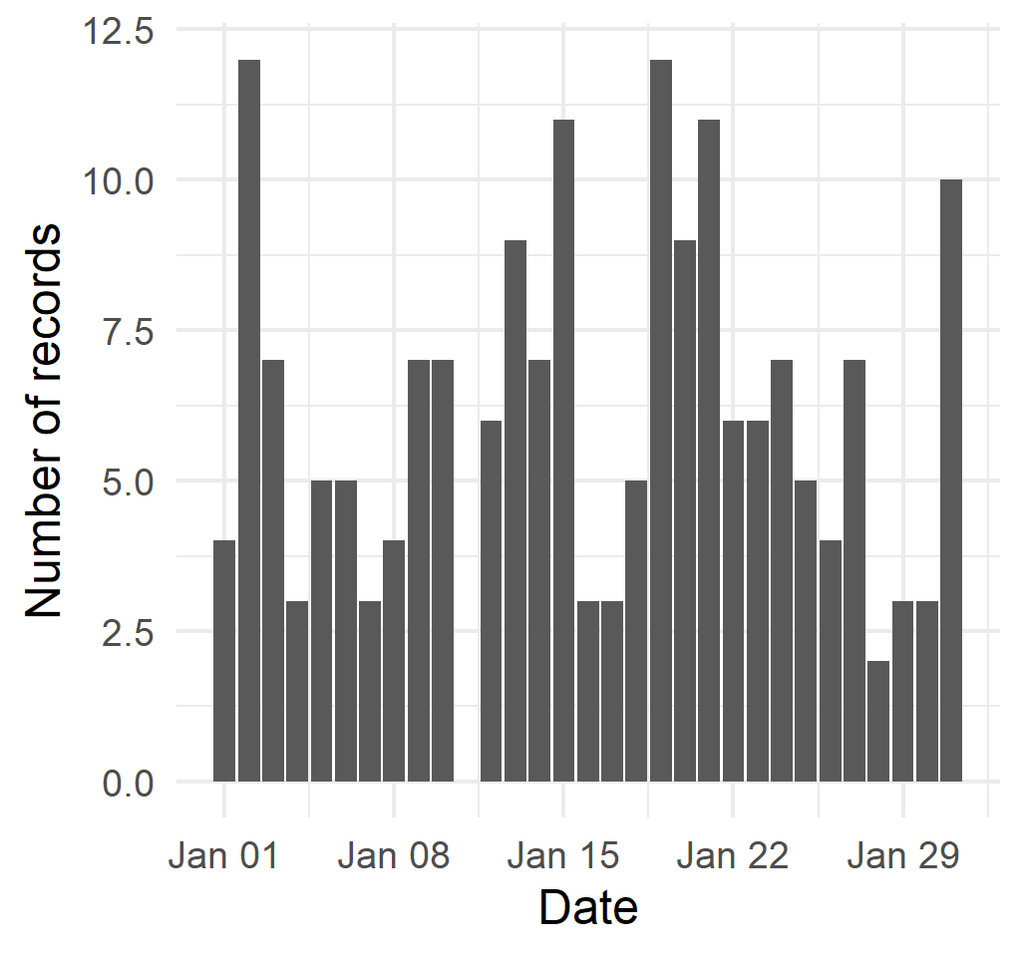

## Add static maps with {ggspatial}

Here are your 186 records plotted on a map.

[figure not shown]

## Include images

And here is an image inserted using R code.

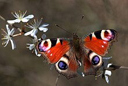

## Buttons and links

Links can be done using markdown syntax such as [this is a link](https://www.irecord.org.uk)

Buttons in emails are not as straightforward as you might think, here’s a way to do it in R.

[Click here](https://www.irecord.org.uk)

This email was generated at 2024-02-01 11:34:20.

Put any disclaimers / information text as a footer in here.

No longer want to receive these emails? Click [here](https://www.irecord.org.uk)